# Multiple linear regression

Using the tools of multiple linear regression to examine correlations among variables in a widely referenced data set.

## Grading the professor

Many college courses conclude by giving students the opportunity to evaluate the course and the instructor anonymously. However, the use of these student evaluations as an indicator of course quality and teaching effectiveness is often criticized because these measures may reflect the influence of non-teaching related characteristics, such as the physical appearance of the instructor. The article titled, “Beauty in the classroom: instructors’ pulchritude and putative pedagogical productivity” (Hamermesh and Parker 2005) found that instructors who are viewed to be better looking receive higher instructional ratings.

In this lab we will analyze the data from this study in order to learn what goes into a positive professor evaluation.

## Getting Started

### Load packages

In this lab we will explore the data using the `dplyr` package and visualize it using the `ggplot2` package for data visualization. The data can be found in the companion package for this course, `statsr`.

Let’s load the packages.

```r
library(statsr)
library(dplyr)
library(ggplot2)
library(GGally)
```

This is the first time we’re using the `GGally` package. We will be using the `ggpairs` function from this package later in the lab.

### The data

The data were gathered from end of semester student evaluations for a large sample of professors from the University of Texas at Austin. In addition, six students rated the professors’ physical appearance. (This is a slightly modified version of the original data set that was released as part of the replication data for *Data Analysis Using Regression and Multilevel/Hierarchical Models* (Gelman and Hill 2007).) The result is a data frame where each row contains a different course and columns represent variables about the courses and professors.

Let’s load the data:

```r
data(evals)
```

| variable | description |
| --- | --- |
| `score` | average professor evaluation score: (1) very unsatisfactory - (5) excellent. |
| `rank` | rank of professor: teaching, tenure track, tenured. |
| `ethnicity` | ethnicity of professor: not minority, minority. |
| `gender` | gender of professor: female, male. |
| `language` | language of school where professor received education: english or non-english. |
| `age` | age of professor. |
| `cls_perc_eval` | percent of students in class who completed evaluation. |
| `cls_did_eval` | number of students in class who completed evaluation. |
| `cls_students` | total number of students in class. |
| `cls_level` | class level: lower, upper. |
| `cls_profs` | number of professors teaching sections in course in sample: single, multiple. |
| `cls_credits` | number of credits of class: one credit (lab, PE, etc.), multi credit. |
| `bty_f1lower` | beauty rating of professor from lower level female: (1) lowest - (10) highest. |
| `bty_f1upper` | beauty rating of professor from upper level female: (1) lowest - (10) highest. |
| `bty_f2upper` | beauty rating of professor from second upper level female: (1) lowest - (10) highest. |
| `bty_m1lower` | beauty rating of professor from lower level male: (1) lowest - (10) highest. |
| `bty_m1upper` | beauty rating of professor from upper level male: (1) lowest - (10) highest. |
| `bty_m2upper` | beauty rating of professor from second upper level male: (1) lowest - (10) highest. |
| `bty_avg` | average beauty rating of professor. |
| `pic_outfit` | outfit of professor in picture: not formal, formal. |
| `pic_color` | color of professor’s picture: color, black & white. |

1. Is this an observational study or an experiment?
   1. Observational study
   2. Experiment

ANSWER: Observational: using already generated data.

2. The original research question posed in the paper is whether beauty leads directly to the differences in course evaluations. Given the study design, should the question be rephrased? If so, how?
   1. No, the question is worded accurately.
   2. Yes, revise wording to “Is there an association between beauty and course evaluations?”
   3. Yes, revise wording to “Does beauty score increase the professor’s course evaluations?”
   4. Yes, revise wording to “Does beauty score decrease the professor’s course evaluations?”

ANSWER: Because this is an observational study, we can talk about correlation but not causation. The question should be rephrased as: “Is there an association between beauty and course evaluations” to reflect this.

## Exploring the data

3. Which of the following statements is **false** about the distribution of `score`?
   1. The median of the distribution is 4.3.
   2. 25% of the students gave their professors a score of over 4.6.
   3. 11 of students gave a professor a score below 3.
   4. The left skewness of the data suggests that the students are less likely to rate the professors highly.

ANSWER: The left skewness… In fact, the responses skew toward rating professors highly. No one wants to admit to buyer’s remorse.

```r
# type your code for Question 3 here, and Knit
summary(evals$score)
```

```
##    Min. 1st Qu.  Median    Mean 3rd Qu.    Max.
##   2.300   3.800   4.300   4.175   4.600   5.000
```

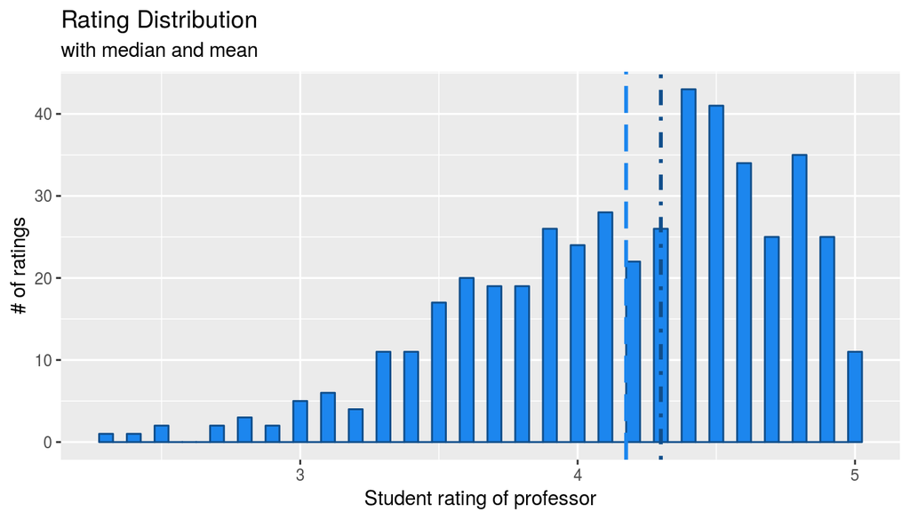

```r
# This shows that the median is, in fact, 4.3, and that the third quartile ceilings at 4.6 (i.e., 25% of students gave their professors a score of over 4.6) -- students at UT Austin like their professors! So the first two suggested responses are true.

# The following histogram will also show that 11 students gave a professor a score below 3 (simple counting via the old eyeball).

# That leaves as the false answer that the "left skewness" (true) suggests students are "less likely" (false -- more likely) to rate their professors highly.

p <- ggplot(data = evals, aes(x = score)) + geom_histogram(binwidth = 0.05, color = "dodgerblue4", fill = "dodgerblue2")
m <- geom_vline(aes(xintercept = mean(score)), color = "dodgerblue2", linetype = "longdash", size = 1)
md <- geom_vline(aes(xintercept = median(score)), color = "dodgerblue4", linetype = "dotdash", size = 1)
l <- labs(x = "Student rating of professor", y = "# of ratings", title = "Rating Distribution", subtitle = "with median and mean")
p + m + md + l
```

```r
# You'll note that I'm using a fairly restrictive bandwith for the histogram, and that all the colors are in the blue range, and specifically within the Dodger blue range. 1957 represent!
```

**Exercise:** Excluding `score`, select two other variables and describe their relationship using an appropriate visualization (scatterplot, side-by-side boxplots, or mosaic plot).

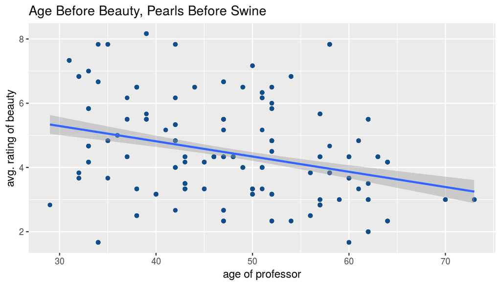

```r
# How does age of professor impact average rating of their beauty?

ggplot(data = evals, aes(x = age, y = bty_avg)) + geom_point(color = "dodgerblue4") +
  geom_smooth(method = lm) +
  labs(title = "Age Before Beauty, Pearls Before Swine", x = "age of professor", y = "avg. rating of beauty")
```

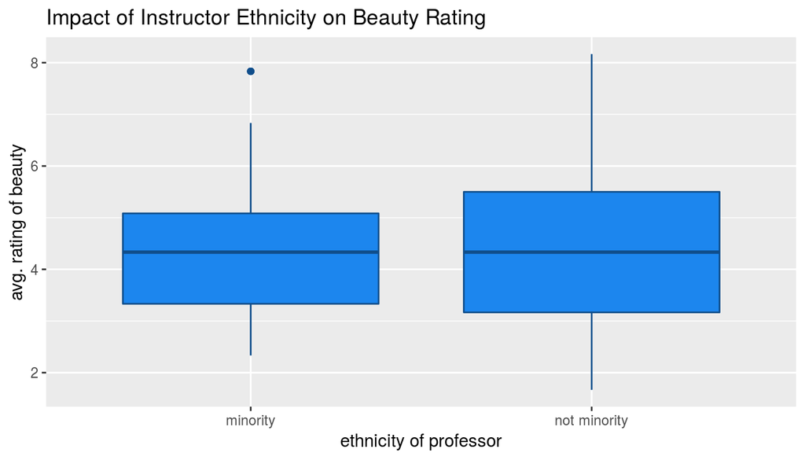

```r
# Interesting... a clear (if dispersed) negative linear association. So...

# How does ethnicity of professor impact average rating of the beauty?

ggplot(data = evals, aes(x = ethnicity, y = bty_avg)) + geom_boxplot(fill = "dodgerblue2", color = "dodgerblue4") +
  labs(title = "Impact of Instructor Ethnicity on Beauty Rating", x = "ethnicity of professor", y = "avg. rating of beauty")
```

```r
# Also interesting, in that it appears to have very little impact (though there is a wider variance for "not-minority" professors).
```

## Simple linear regression

The fundamental phenomenon suggested by the study is that better looking teachers are evaluated more favorably. Let’s create a scatterplot to see if this appears to be the case:

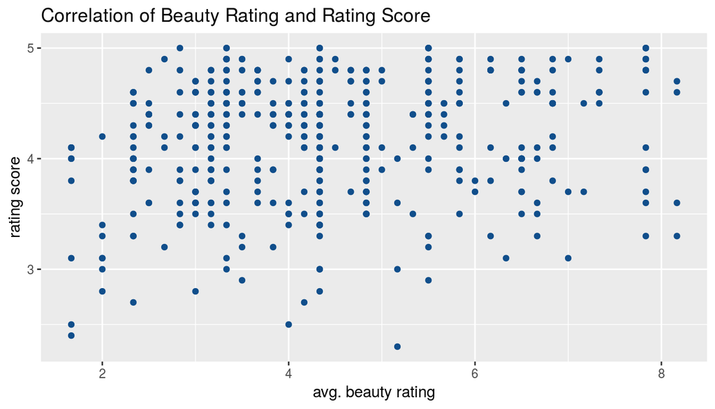

```r
ggplot(data = evals, aes(x = bty_avg, y = score)) +
  geom_point(color = "dodgerblue4") +
  labs(title = "Correlation of Beauty Rating and Rating Score", x = "avg. beauty rating", y = "rating score")
```

Before we draw conclusions about the trend, compare the number of observations in the data frame with the approximate number of points on the scatterplot. Is anything awry?

Notice that you’d expect many more data points. This is because, due to the limited number of levels on both the x- and y-axis, many individual observations are hidden behind duplicate matrix positions.

**Exercise:** Replot the scatterplot, but this time replace the `geom_point()` layer with a `geom_jitter()` layer. (Use `?geom_jitter` to learn more.) What was misleading about the initial scatterplot?

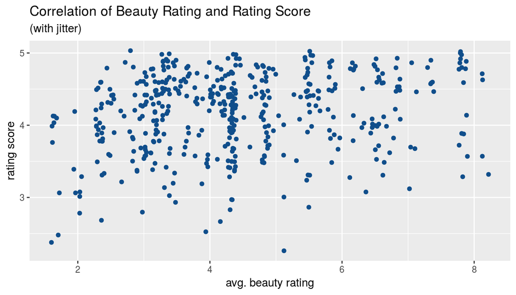

```r
# type your code for the Exercise here, and Knit

ggplot(data = evals, aes(x = bty_avg, y = score)) +
  geom_jitter(color = "dodgerblue4") +
  labs(title = "Correlation of Beauty Rating and Rating Score", x = "avg. beauty rating", y = "rating score", subtitle = "(with jitter)")
```

Let’s see if the apparent trend in the plot is something more than natural variation. Fit a linear model called `m_bty` to predict average professor score by average beauty rating and add the line to your plot using the following. If you do not remember how to do this, refer to the previous lab.

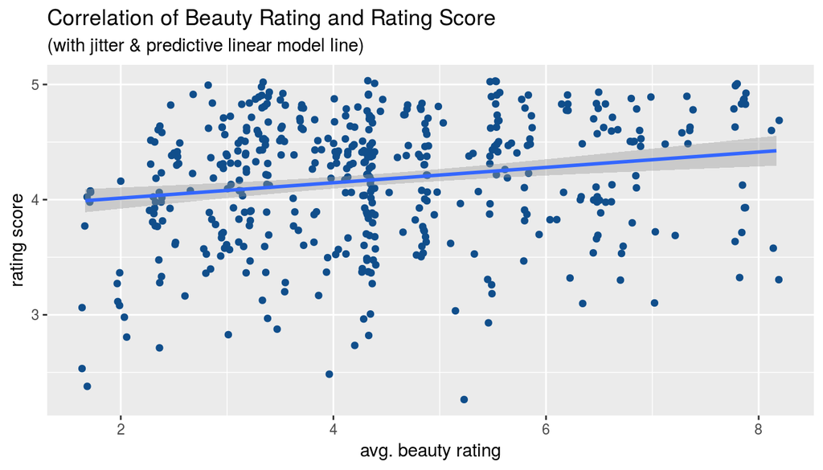

```r
ggplot(data = evals, aes(x = bty_avg, y = score)) +
  geom_jitter(color = "dodgerblue4") +
  geom_smooth(method = "lm") +
  labs(title = "Correlation of Beauty Rating and Rating Score", x = "avg. beauty rating", y = "rating score", subtitle = "(with jitter & predictive linear model line)")
```

The blue line is the model. The shaded gray area around the line tells us about the variability we might expect in our predictions. To turn that off, use `se = FALSE`.

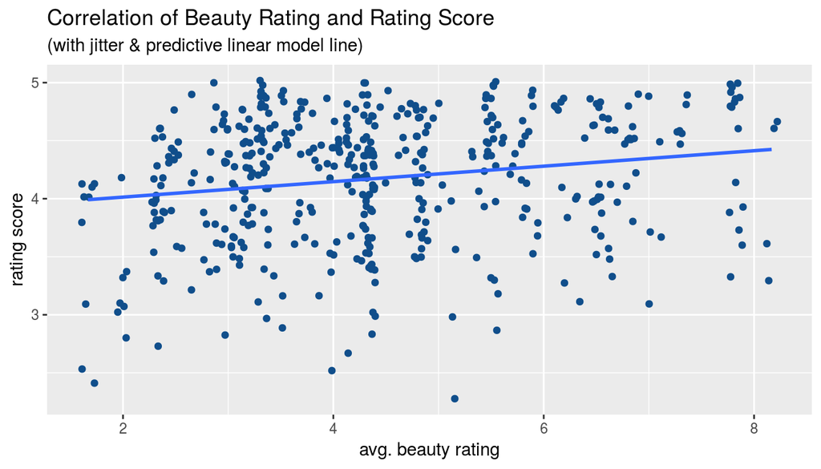

```r
ggplot(data = evals, aes(x = bty_avg, y = score)) +
  geom_jitter(color = "dodgerblue4") +
  geom_smooth(method = "lm", se = FALSE) +
  labs(title = "Correlation of Beauty Rating and Rating Score", x = "avg. beauty rating", y = "rating score", subtitle = "(with jitter & predictive linear model line)")
```

**Exercise:** Print a summary of the linear model, write out the equation, and interpret the slope.

```r
m_bty <- lm(data = evals, score ~ bty_avg)
summary(m_bty)
```

```
##
## Call:
## lm(formula = score ~ bty_avg, data = evals)
##
## Residuals:
##     Min      1Q  Median      3Q     Max
## -1.9246 -0.3690  0.1420  0.3977  0.9309
##
## Coefficients:
##             Estimate Std. Error t value Pr(>|t|)
## (Intercept)  3.88034    0.07614   50.96  < 2e-16 ***
## bty_avg      0.06664    0.01629    4.09 5.08e-05 ***
## ---
## Signif. codes:  0 '***' 0.001 '**' 0.01 '*' 0.05 '.' 0.1 ' ' 1
##
## Residual standard error: 0.5348 on 461 degrees of freedom
## Multiple R-squared:  0.03502,    Adjusted R-squared:  0.03293
## F-statistic: 16.73 on 1 and 461 DF,  p-value: 5.083e-05
```

NOTE: The equation for the linear model of the association between evaluation `score` and rated `bty_avg` (beauty) is

$$\hat{score} = 3.88 + 0.067{bty\_avg}$$

Meaning, that each one-point increase in the average beauty rating for a professor is associated with a positive (if small) 0.067 increase in evaluation score. Though small, the model suggests that the association is statistically significant, at close to a p-value of 0 (i.e., with 95% confidence, we can say that there are close to zero situations in which simple sampling variation would produce a variance of this magnitude).

4. Average beauty score is a statistically significant predictor of evaluation score.
   1. True
   2. False

ANSWER: True. See explanation above.

5. Use residual plots to evaluate whether the conditions of least squares regression are reasonable. Which of the following statements is an incorrect analysis of the residual plots and conditions?
   1. Linear association: The residuals plot shows a random scatter.
   2. Constant variance of residuals: No fan shape in residuals plot.
   3. Nearly normal residuals: Residuals are right skewed, but the sample size is large, so this may not be an important violation of conditions.
   4. Independent observations: Classes sampled randomly, no order effect.

ANSWER: Results are LEFT-SKEWED, but the sample size is large, so this may not be an important violation of conditions.

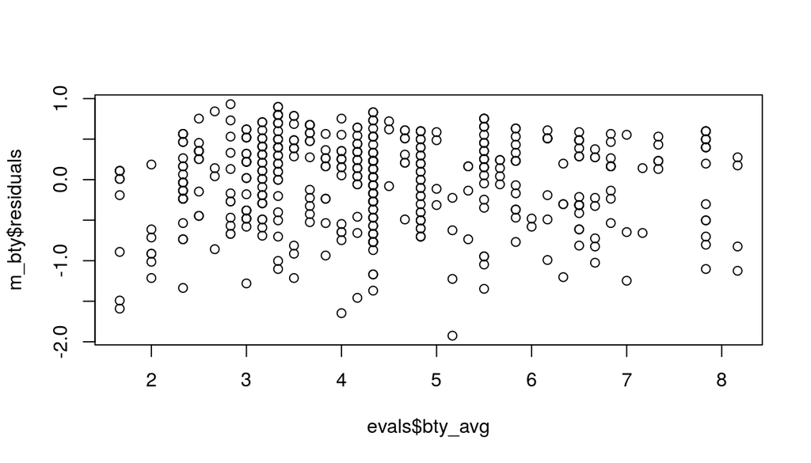

```r
# There are several ways to test whether the conditions of least squares regression hold in this case.
# A residuals plot can show whether scatter around the line of zero divergence from the predicted value is more or less random (here, they seem to be just that):

plot(m_bty$residuals ~ evals$bty_avg)
```

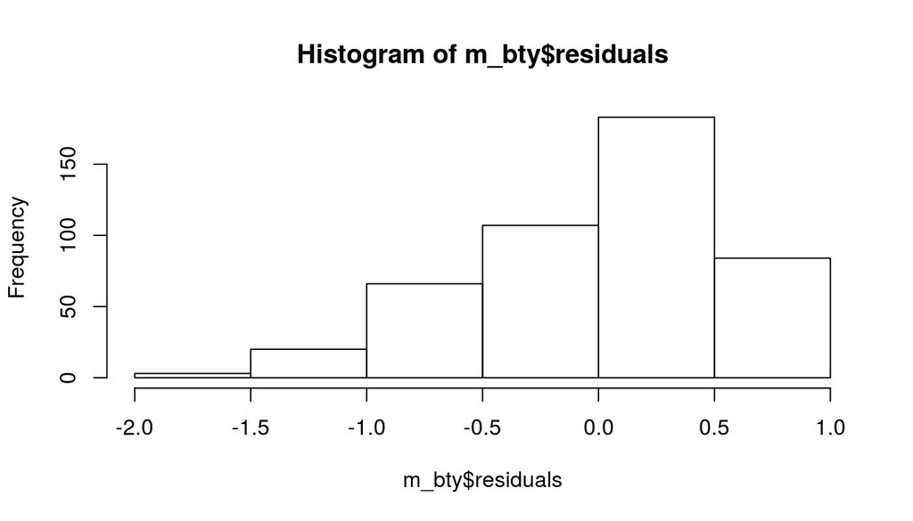

```r
# A histogram can show whether there's a nearly normal distribution of residuals around zero (here we see some left skew, but the large sample size balances out what otherwise might be a warning sign)

hist(m_bty$residuals)
```

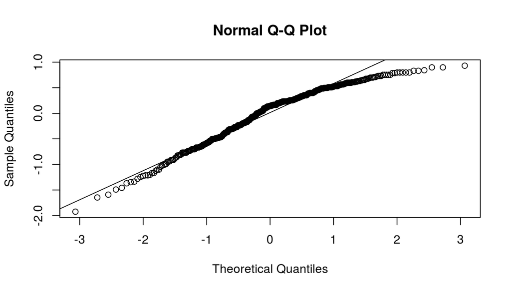

```r
# A normal probability plot should likewise show the residuals hewing pretty closely and consistently to the predicted values along the range of predicted values (again, here we get greater divergence at the higher end, balanced by large sample size)

qqnorm(m_bty$residuals)
qqline(m_bty$residuals)
```

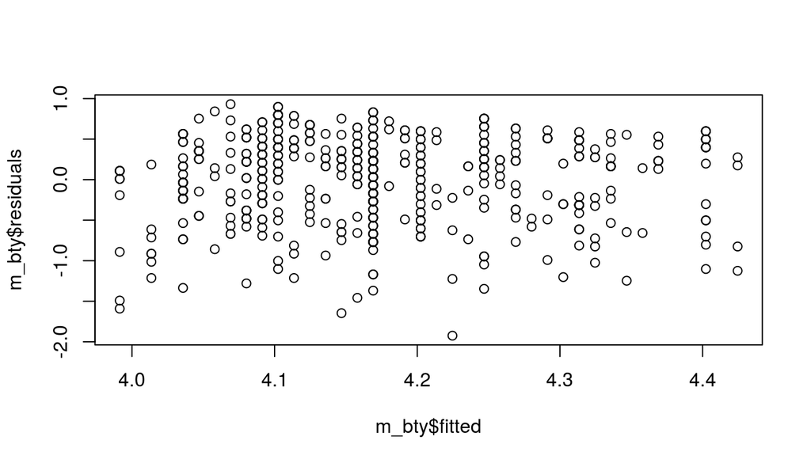

```r
# Likewise, variation in the residuals should remain constant along the range of the response variable, and we would want to see no fan shape in our residuals vs. fitted plot, and no triangle shape in a version of this framed in terms of the absolute value of the residuals.

plot(m_bty$residuals ~ m_bty$fitted)
```

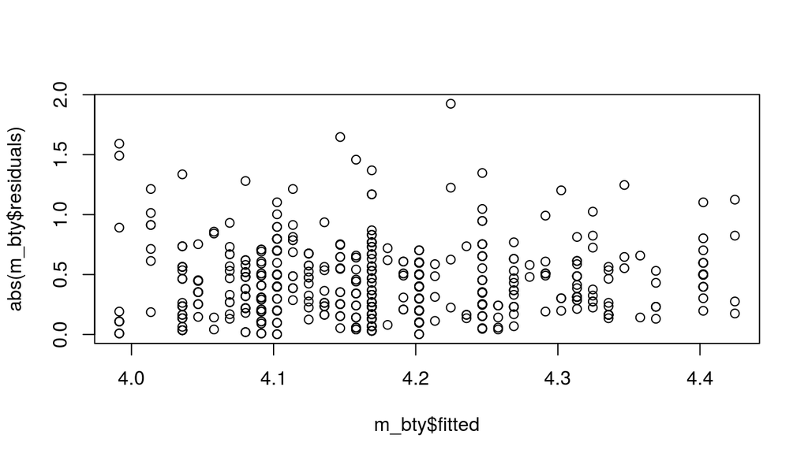

```r
plot(abs(m_bty$residuals) ~ m_bty$fitted)
```

```r
# In this case, the order of collection isn't an issue, since all observations were collected -- as far as we know -- independently.
```

## Multiple linear regression

The data set contains several variables on the beauty score of the professor: individual ratings from each of the six students who were asked to score the physical appearance of the professors and the average of these six scores. Let’s take a look at the relationship between one of these scores and the average beauty score.

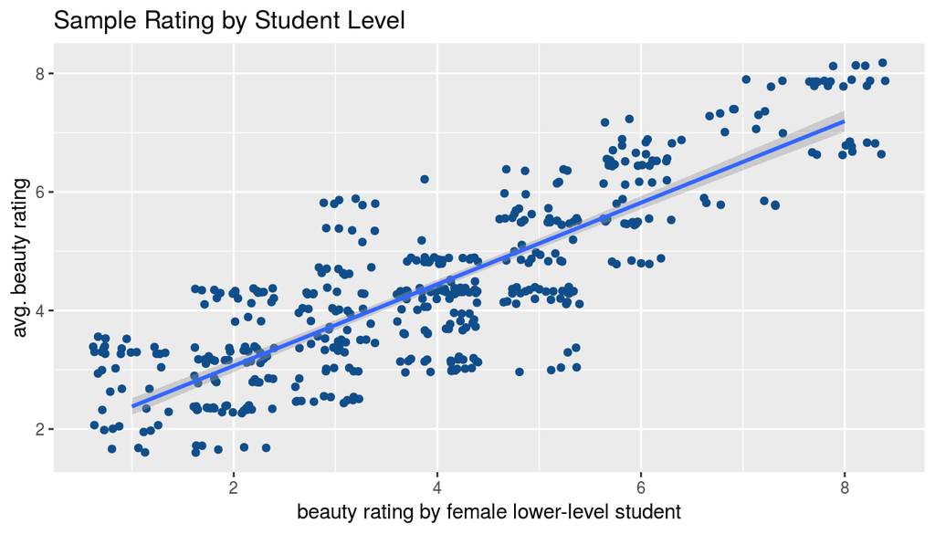

```r
ggplot(data = evals, aes(x = bty_f1lower, y = bty_avg)) +
  geom_jitter(color = "dodgerblue4") +
  geom_smooth(method = "lm") +
  labs(title = "Sample Rating by Student Level", x = "beauty rating by female lower-level student", y = "avg. beauty rating")
```

```r
evals %>%
  summarise(cor(bty_avg, bty_f1lower))
```

```
## # A tibble: 1 x 1
##   `cor(bty_avg, bty_f1lower)`
##                         <dbl>
## 1                       0.844
```

As expected the relationship is quite strong - after all, the average score is calculated using the individual scores.

We can actually take a look at the relationships between all beauty variables (columns 13 through 19) using the following command:

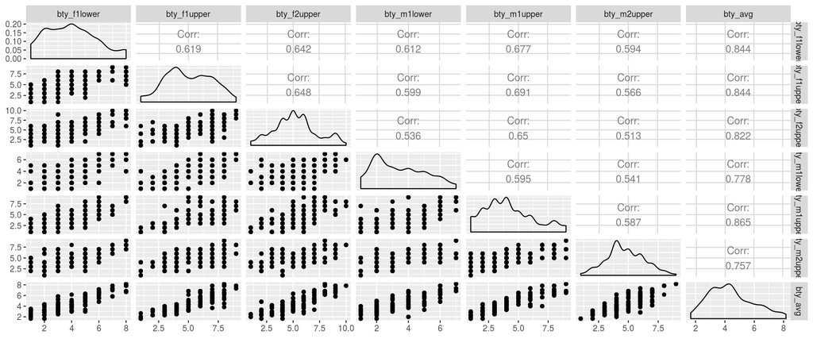

```r
ggpairs(evals, columns = 13:19)
```

These variables are collinear (correlated), and adding more than one of these variables to the model would not add much value to the model. In this application and with these highly-correlated predictors, it is reasonable to use the average beauty score as the single representative of these variables.

NOTE: In other words, the class or gender status of the rater does not seem to add any significant new information to the question of how the professor’s beauty/ratings is generated.

In order to see if beauty is still a significant predictor of professor score after we’ve accounted for the gender of the professor, we can add the gender term into the model.

```r
# Multiple linear regression, with beauty rating and gender or professor as explanatory variables

m_bty_gen <- lm(score ~ bty_avg + gender, data = evals)
summary(m_bty_gen)
```

```
##
## Call:
## lm(formula = score ~ bty_avg + gender, data = evals)
##
## Residuals:
##     Min      1Q  Median      3Q     Max
## -1.8305 -0.3625  0.1055  0.4213  0.9314
##
## Coefficients:
##             Estimate Std. Error t value Pr(>|t|)
## (Intercept)  3.74734    0.08466  44.266  < 2e-16 ***
## bty_avg      0.07416    0.01625   4.563 6.48e-06 ***
## gendermale   0.17239    0.05022   3.433 0.000652 ***
## ---
## Signif. codes:  0 '***' 0.001 '**' 0.01 '*' 0.05 '.' 0.1 ' ' 1
##
## Residual standard error: 0.5287 on 460 degrees of freedom
## Multiple R-squared:  0.05912,    Adjusted R-squared:  0.05503
## F-statistic: 14.45 on 2 and 460 DF,  p-value: 8.177e-07
```

6. P-values and parameter estimates should only be trusted if the conditions for the regression are reasonable. Using diagnostic plots, we can conclude that the conditions for this model are reasonable.
   1. True
   2. False

ANSWER: True - the distribution of residuals is random, there is some left-skew (as before) balanced out by sample size, a normal shape to our probability plot, and constant variability more or less across both the range of responses.

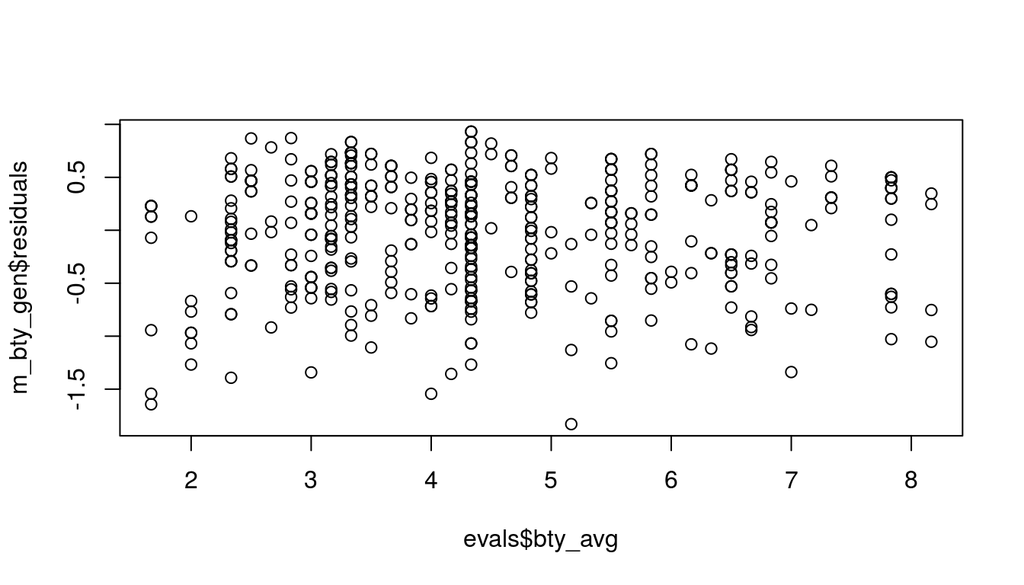

```r
# type your code for the Exercise here, and Knit

# Random scatter of residuals?

plot(m_bty_gen$residuals ~ evals$bty_avg)
```

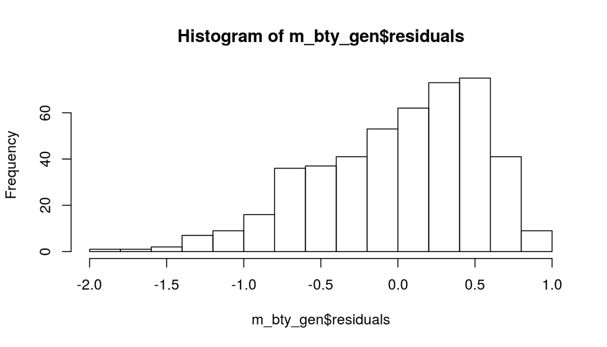

```r
# Normal distribution of residuals?

hist(m_bty_gen$residuals)
```

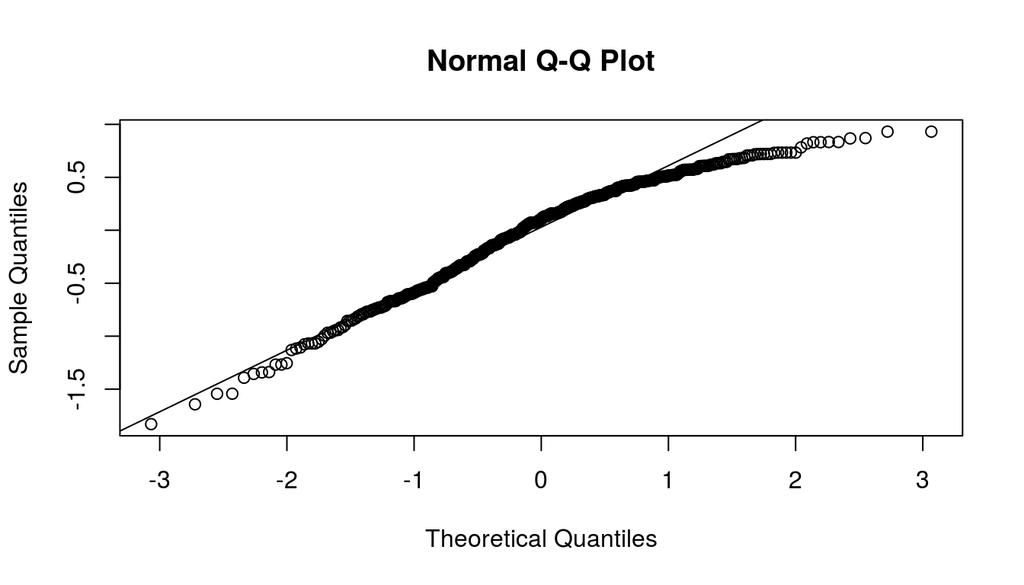

```r
# Normal probability plots?

qqnorm(m_bty_gen$residuals)
qqline(m_bty_gen$residuals)
```

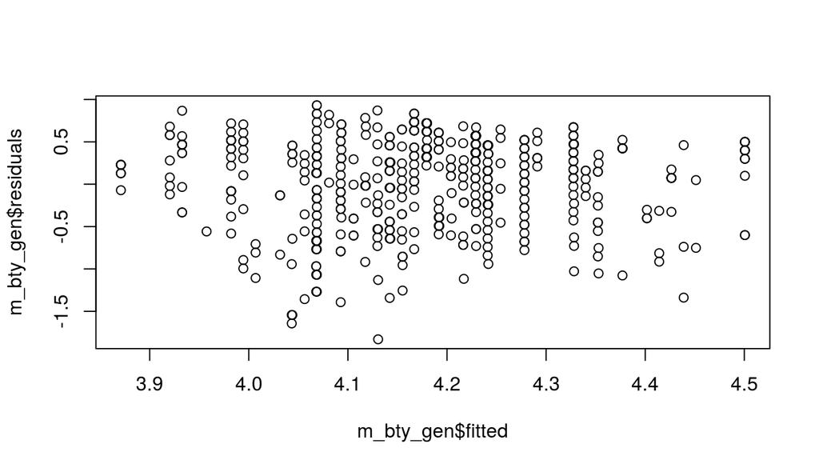

```r
# Constant variability across range of response variable?

plot(m_bty_gen$residuals ~ m_bty_gen$fitted)
```

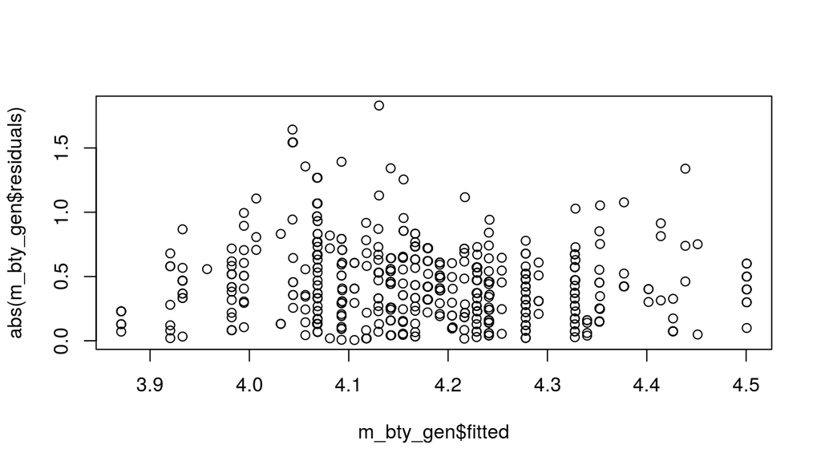

```r
plot(abs(m_bty_gen$residuals) ~ m_bty_gen$fitted)
```

**Exercise:** Print a summary of the multiple linear regression model. Is `bty_avg` still a significant predictor of `score`? Has the addition of `gender` to the model changed the parameter estimate for `bty_avg`?

```r
# Summary of multiple linear regression model

summary(m_bty_gen)
```

```
##
## Call:
## lm(formula = score ~ bty_avg + gender, data = evals)
##
## Residuals:
##     Min      1Q  Median      3Q     Max
## -1.8305 -0.3625  0.1055  0.4213  0.9314
##
## Coefficients:
##             Estimate Std. Error t value Pr(>|t|)
## (Intercept)  3.74734    0.08466  44.266  < 2e-16 ***
## bty_avg      0.07416    0.01625   4.563 6.48e-06 ***
## gendermale   0.17239    0.05022   3.433 0.000652 ***
## ---
## Signif. codes:  0 '***' 0.001 '**' 0.01 '*' 0.05 '.' 0.1 ' ' 1
##
## Residual standard error: 0.5287 on 460 degrees of freedom
## Multiple R-squared:  0.05912,    Adjusted R-squared:  0.05503
## F-statistic: 14.45 on 2 and 460 DF,  p-value: 8.177e-07
```

Results: `bty_avg` is still a significant predictor of a professor’s rating `score`, with the p-value of the `bty_avg` coefficient still very close to zero. Interestingly, adding the `gender` variable has had the effect of increasing the value of the `bty_avg` coefficient and lower its p-value. In addition, both the R-squared and Adjusted R-squared value of the model are greater.

Note that the estimate for `gender` is now called `gendermale`. You’ll see this name change whenever you introduce a categorical variable. The reason is that R recodes `gender` from having the values of `female` and `male` to being an indicator variable called `gendermale` that takes a value of $0$ for females and a value of $1$ for males. (Such variables are often referred to as “dummy” variables.)

As a result, for females, the parameter estimate is multiplied by zero, leaving the intercept and slope form familiar from simple regression.

$$\begin{aligned}
\widehat{score} &= \hat{\beta}_0 + \hat{\beta}_1 \times bty\_avg + \hat{\beta}_2 \times (0) \\
&= \hat{\beta}_0 + \hat{\beta}_1 \times bty\_avg\end{aligned}$$

7. For two professors (one male and one female) who received the same beauty rating, the male professor is predicted to have the higher course evaluation score than the female.
   1. True
   2. False

ANSWER: True. The condition of a professor being male correlates with a predicted score $0.17$ points higher than if that same professor were female, all other things being equal.

The decision to call the indicator variable `gendermale` instead of`genderfemale` has no deeper meaning. R simply codes the category that comes first alphabetically as a $0$. (You can change the reference level of a categorical variable, which is the level that is coded as a 0, using the`relevel` function. Use `?relevel` to learn more.)

**Exercise:** Create a new model called `m_bty_rank` with `gender` removed and `rank` added in. How does R appear to handle categorical variables that have more than two levels? Note that the rank variable has three levels: teaching, tenure track, tenured.

```r
# Multi-leveled categorical explanatory variables.

m_bty_rank = lm(data = evals, score ~ bty_avg + rank)
summary(m_bty_rank)
```

```
##
## Call:
## lm(formula = score ~ bty_avg + rank, data = evals)
##
## Residuals:
##     Min      1Q  Median      3Q     Max
## -1.8713 -0.3642  0.1489  0.4103  0.9525
##
## Coefficients:
##                  Estimate Std. Error t value Pr(>|t|)
## (Intercept)       3.98155    0.09078  43.860  < 2e-16 ***
## bty_avg           0.06783    0.01655   4.098 4.92e-05 ***
## ranktenure track -0.16070    0.07395  -2.173   0.0303 *
## ranktenured      -0.12623    0.06266  -2.014   0.0445 *
## ---
## Signif. codes:  0 '***' 0.001 '**' 0.01 '*' 0.05 '.' 0.1 ' ' 1
##
## Residual standard error: 0.5328 on 459 degrees of freedom
## Multiple R-squared:  0.04652,    Adjusted R-squared:  0.04029
## F-statistic: 7.465 on 3 and 459 DF,  p-value: 6.88e-05
```

The status of “teaching” for `rank` is treated as the zero-added default, with a $1$ value for `ranktenure track` decreasing the predicted score by $-0.16$ points, and `ranktenured` decreasing it by $-0.13$.

8. Which of the following is the correct order of the three levels of rank if we were to order them from lowest predicted course evaluation score to highest predicted course evaluation score?
   1. Teaching, Tenure Track, Tenured
   2. Tenure track, Tenured
   3. Tenure Track, Tenured, Teaching
   4. Teaching, Tenured, Tenure Track

ANSWER: Tenure Track, Tenured, Teaching

The interpretation of the coefficients in multiple regression is slightly different from that of simple regression. The estimate for `bty_avg` reflects how much higher a group of professors is expected to score if they have a beauty rating that is one point higher *while holding all other variables constant*. In this case, that translates into considering only professors of the same rank with `bty_avg` scores that are one point apart.

```r
# R treats the first alphabetical value of a multi-level categorical variable as the default (adding or subtracting nothing from the predicted response variable), then treating each other value choice as its own binary variable relative to that default.
```

## Prediction

Suppose we want to use the model we created earlier, `m_bty_gen` to predict the evaluation score for a professor, Dr. Hypo Thetical, who is a male tenure track professor with an average beauty of 3.

If we wanted to do this by hand, we would simply plug in these values into the linear model.

We can also calculate the predicted value in R.

First, we need to create a new data frame for this professor.

```r
newprof <- data.frame(gender = "male", bty_avg = 3)
```

Note that I didn’t need to add `rank = "tenure track"` to this data frame since this variable is not used in our model.

Then, I can do the prediction using the `predict` function:

```r
predict(m_bty_gen, newprof)
```

```
##        1
## 4.142194
```

We can also construct a prediction interval around this prediction, which will provide a measure of uncertainty around the prediction.

```r
predict(m_bty_gen, newprof, interval = "prediction", level = 0.95)
```

```
##        fit      lwr      upr
## 1 4.142194 3.100559 5.183829
```

Hence, the model predicts, with 95% confidence, that a male professor with an average beauty score of 3 is expected to have an evaluation score between 3.1 and 5.18.

## The search for the best model

We will start with a full model that predicts professor score based on rank, ethnicity, gender, language of the university where they got their degree, age, proportion of students that filled out evaluations, class size, course level, number of professors, number of credits, average beauty rating, outfit, and picture color.

Which variable would you expect to have the highest p-value in this model? Why? *Hint:* Think about which variable would you expect to not have any association with the professor score.

Let’s run the model…

```r
m_full <- lm(score ~ rank + ethnicity + gender + language + age + cls_perc_eval
             + cls_students + cls_level + cls_profs + cls_credits + bty_avg
             + pic_outfit + pic_color, data = evals)
summary(m_full)
```

```
##
## Call:
## lm(formula = score ~ rank + ethnicity + gender + language + age +
##     cls_perc_eval + cls_students + cls_level + cls_profs + cls_credits +
##     bty_avg + pic_outfit + pic_color, data = evals)
##
## Residuals:
##      Min       1Q   Median       3Q      Max
## -1.77397 -0.32432  0.09067  0.35183  0.95036
##
## Coefficients:
##                         Estimate Std. Error t value Pr(>|t|)
## (Intercept)            4.0952141  0.2905277  14.096  < 2e-16 ***
## ranktenure track      -0.1475932  0.0820671  -1.798  0.07278 .
## ranktenured           -0.0973378  0.0663296  -1.467  0.14295
## ethnicitynot minority  0.1234929  0.0786273   1.571  0.11698
## gendermale             0.2109481  0.0518230   4.071 5.54e-05 ***
## languagenon-english   -0.2298112  0.1113754  -2.063  0.03965 *
## age                   -0.0090072  0.0031359  -2.872  0.00427 **
## cls_perc_eval          0.0053272  0.0015393   3.461  0.00059 ***
## cls_students           0.0004546  0.0003774   1.205  0.22896
## cls_levelupper         0.0605140  0.0575617   1.051  0.29369
## cls_profssingle       -0.0146619  0.0519885  -0.282  0.77806
## cls_creditsone credit  0.5020432  0.1159388   4.330 1.84e-05 ***
## bty_avg                0.0400333  0.0175064   2.287  0.02267 *
## pic_outfitnot formal  -0.1126817  0.0738800  -1.525  0.12792
## pic_colorcolor        -0.2172630  0.0715021  -3.039  0.00252 **
## ---
## Signif. codes:  0 '***' 0.001 '**' 0.01 '*' 0.05 '.' 0.1 ' ' 1
##
## Residual standard error: 0.498 on 448 degrees of freedom
## Multiple R-squared:  0.1871, Adjusted R-squared:  0.1617
## F-statistic: 7.366 on 14 and 448 DF,  p-value: 6.552e-14
```

**Exercise:** Check your suspicions from the previous exercise. Include the model output in your response.

9. Which of the following is the correct intrepetation of the coefficient associated with the ethnicity variable.  
   Non-minority professors are expected on average to score …
   1. 0.12 points lower than minority professors, all else held constant.
   2. 0.12 points higher than minority professors, all else held constant.
   3. 0.02 points lower than minority professors, all else held constant.
   4. 0.02 points higher than minority professors, all else held constant.

ANSWER: From the full model, we would expect that non-minority professors would score 0.12 points higher than minority professors, all else held constant. Though the p-value of 0.11698 suggests that the predictive value of this variable is not significant at the 95% confidence level we’re trying to work with.

**Exercise:** Drop the variable with the highest p-value and re-fit the model. Did the coefficients and significance of the other explanatory variables change? (One of the things that makes multiple regression interesting is that coefficient estimates depend on the other variables that are included in the model.) If not, what does this say about whether or not the dropped variable was collinear with the other explanatory variables?

```r
# Dropping `cls_profs`

m_select <- lm(score ~ rank + ethnicity + gender + language + age + cls_perc_eval
             + cls_students + cls_level + cls_credits + bty_avg
             + pic_outfit + pic_color, data = evals)
summary(m_select)
```

```
##
## Call:
## lm(formula = score ~ rank + ethnicity + gender + language + age +
##     cls_perc_eval + cls_students + cls_level + cls_credits +
##     bty_avg + pic_outfit + pic_color, data = evals)
##
## Residuals:
##     Min      1Q  Median      3Q     Max
## -1.7836 -0.3257  0.0859  0.3513  0.9551
##
## Coefficients:
##                         Estimate Std. Error t value Pr(>|t|)
## (Intercept)            4.0872523  0.2888562  14.150  < 2e-16 ***
## ranktenure track      -0.1476746  0.0819824  -1.801 0.072327 .
## ranktenured           -0.0973829  0.0662614  -1.470 0.142349
## ethnicitynot minority  0.1274458  0.0772887   1.649 0.099856 .
## gendermale             0.2101231  0.0516873   4.065 5.66e-05 ***
## languagenon-english   -0.2282894  0.1111305  -2.054 0.040530 *
## age                   -0.0089992  0.0031326  -2.873 0.004262 **
## cls_perc_eval          0.0052888  0.0015317   3.453 0.000607 ***
## cls_students           0.0004687  0.0003737   1.254 0.210384
## cls_levelupper         0.0606374  0.0575010   1.055 0.292200
## cls_creditsone credit  0.5061196  0.1149163   4.404 1.33e-05 ***
## bty_avg                0.0398629  0.0174780   2.281 0.023032 *
## pic_outfitnot formal  -0.1083227  0.0721711  -1.501 0.134080
## pic_colorcolor        -0.2190527  0.0711469  -3.079 0.002205 **
## ---
## Signif. codes:  0 '***' 0.001 '**' 0.01 '*' 0.05 '.' 0.1 ' ' 1
##
## Residual standard error: 0.4974 on 449 degrees of freedom
## Multiple R-squared:  0.187,  Adjusted R-squared:  0.1634
## F-statistic: 7.943 on 13 and 449 DF,  p-value: 2.336e-14
```

Now we try a different model selection method: adjusted $R^2$. Create a new model, `m1`, where you remove `rank` from the list of explanatory variables. Check out the adjusted $R^2$ of this new model and compare it to the adjusted $R^2$ of the full model.

```r
m1 <- lm(score ~ ethnicity + gender + language + age + cls_perc_eval
             + cls_students + cls_level + cls_profs + cls_credits + bty_avg, data = evals)
summary(m1)$adj.r.squared
```

[output not shown]

Then, try dropping the next variable from the full model (`ethnicity`):

```r
m2 = lm(score ~ rank + gender + language + age + cls_perc_eval +
    cls_students + cls_level + cls_profs + cls_credits + bty_avg, data = evals)
summary(m2)$adj.r.squared
```

[output not shown]

**Exercise:** Repeat this process until you have tried removing each variable from the full model at a time, and determine removal of which variable yields the highest improvement in the adjusted $R^2$.

```r
# removing gender

m_test = lm(score ~ rank + ethnicity + language + age + cls_perc_eval +
    cls_students + cls_level + cls_profs + cls_credits + bty_avg, data = evals)
summary(m_test)$adj.r.squared
```

```
## [1] 0.1202468
```

```r
# removing language

m_test = lm(score ~ rank + ethnicity + gender + age + cls_perc_eval +
    cls_students + cls_level + cls_profs + cls_credits + bty_avg, data = evals)
summary(m_test)$adj.r.squared
```

```
## [1] 0.1404972
```

```r
# removing age

m_test = lm(score ~ rank + ethnicity + gender + language + cls_perc_eval +
    cls_students + cls_level + cls_profs + cls_credits + bty_avg, data = evals)
summary(m_test)$adj.r.squared
```

```
## [1] 0.1342627
```

```r
# removing percentage of class completing the evaluation

m_test = lm(score ~ rank + ethnicity + gender + language + age +
    cls_students + cls_level + cls_profs + cls_credits + bty_avg, data = evals)
summary(m_test)$adj.r.squared
```

```
## [1] 0.1174213
```

```r
# removing class students

m_test = lm(score ~ rank + ethnicity + gender + language + age +
    cls_perc_eval + cls_level + cls_profs + cls_credits + bty_avg, data = evals)
summary(m_test)$adj.r.squared
```

```
## [1] 0.1401804
```

```r
# removing class level

m_test = lm(score ~ rank + ethnicity + gender + language + age +
    cls_perc_eval + cls_students + cls_profs + cls_credits + bty_avg, data = evals)
summary(m_test)$adj.r.squared
```

```
## [1] 0.1429056
```

```r
# removing number of profs

m_test = lm(score ~ rank + ethnicity + gender + language + age +
    cls_perc_eval + cls_students + cls_level + cls_credits + bty_avg, data = evals)
summary(m_test)$adj.r.squared
```

```
## [1] 0.1430683
```

```r
# removing class credits

m_test = lm(score ~ rank + ethnicity + gender + language + age +
    cls_perc_eval + cls_students + cls_level + cls_profs + bty_avg, data = evals)
summary(m_test)$adj.r.squared
```

```
## [1] 0.107127
```

```r
# removing beauty score

m_test = lm(score ~ rank + ethnicity + gender + language + age +
    cls_perc_eval + cls_students + cls_level + cls_profs + cls_credits, data = evals)
summary(m_test)$adj.r.squared
```

```
## [1] 0.1174189
```

```r
# full model

m_test = lm(score ~ rank + ethnicity + gender + language + age +
    cls_perc_eval + cls_students + cls_level + cls_profs + cls_credits + bty_avg, data = evals)
summary(m_test)$adj.r.squared
```

```
## [1] 0.1412172
```

10. Elimination of which variable from the full model yielded the highest adjusted R-squared?
    1. `bty_avg`
    2. `cls_profs`
    3. `cls_students`
    4. `rank`

To complete the model selection we would continue removing variables one at a time until removal of another variable did not increase adjusted $R^2$.

**Exercise:** The original paper describes how these data were gathered by taking a sample of professors from the University of Texas at Austin and including all courses that they have taught. Considering that each row represents a course, could this new information have an impact on any of the conditions of linear regression?

ANSWER: Possibly. Since some professors are presumably teaching more courses than others, the results for those professors may have an outsized impact on the overall results (esp. if they were outliers). And in addition, this information suggests that the observations are not entirely independent, since a student’s opinion of a professor from one class may have an impact on their rating of the professor if they were taking a second class with them.

If the data is collected over multiple semesters, this may be an even more significant time-series issue: a professor’s rating from one semester might carry over into another, encouraging students likely to be receptive to that professor’s style or approach to self-select as observers.

**Exercise:** Based on your final model, describe the characteristics of a professor and course at University of Texas at Austin that would be associated with a high evaluation score.

A professor at UT Austin associated with a high score would most significantly be predicted if that professor were a male teaching a one credit course with a high percentage of students completing the evaluations. Other potentially significant qualities of the professor/course would be a younger age of the professor and (oddly) whether their profile picture was black-and-white.

Interestingly, given the premise of the study, the average beauty rating of the instructor was only marginally significant at the 95% confidence level, with a p-value of $0.023$ – just under the $0.025$ cutoff for a two-tailed measure at $0.95$.

**Exercise:** Would you be comfortable generalizing your conclusions to apply to professors generally (at any university)? Why or why not?

No. As a public 4-year residential university with a strong academic reputation in unique city in a unique state, the University of Texas Austin may not be representative of the wide range of private, commuter, two-year, for-profit, Northern, Eastern, international, or other factors that make up the very diverse kinds of educational experiences that constitute higher education in the current moment.

This is a product of OpenIntro that is released under a [Creative Commons Attribution-ShareAlike 3.0 Unported](http://creativecommons.org/licenses/by-sa/3.0). This lab was written by Mine Çetinkaya-Rundel and Andrew Bray.

## References

Gelman, Andrew, and Jennifer Hill. 2007. *Data Analysis Using Regression and Multilevel/Hierarchical Models*. 1st ed. Cambridge University Press.

Hamermesh, Daniel S., and Amy Parker. 2005. “Beauty in the Classroom - Instructors’ Pulchritude and Putative Pedagogical Productivity” 24 (4). Economics of Education Review: 369–76. doi:10.1016/j.econedurev.2004.07.013.